# Additional File 1 – Supplement S1-S11

Authors

Marian Eberl

Luana F. Tanaka

Klaus Kraywinkel

Stefanie J. Klug

Published

03 May 2024

Keywords

lung cancer, second primary cancer, cancer registry data, cancer epidemiology, standardized incidence ratio

# Additional File 1 - Supplement S1-S11

Supplementary information for the paper

*“Histology-specific standardized incidence ratio improves the estimation of second primary lung cancer risk”*

Authors: Eberl M, Tanaka LF, Kraywinkel K, Klug SJ

Correspondence: Marian Eberl, marian.eberl@tum.de, Chair of Epidemiology, TUM School of Medicine and Health, Technical University of Munich, Munich, Germany

## Table S1: Comparison of IARC/IACR and SEER multiple primary rules

Supplement Table S1: Comparison of IARC/IACR and SEER multiple primary rules

IARC/IACR MP rules

SEER MP rules

Expected  
incidence of SPLC

**Timing**

irrelevant

- after 1-5 “disease-free” years [3 years for lung cancer] the exact same cancer (location, behavior, histology, laterality) will be recorded as ✅ SPC

- after 60 days the same cancer (location, histology, laterality) with different behavior will be recorded as ✅ SPC

higher SPLC incidence for SEER MP rules

**Location**

- different organ: ✅ SPC

- same organ: ❌ no SPC

different location (mostly at third topography character, i.e. C33 is different from C34): ✅ SPC

higher SPLC incidence for SEER MP rules

**Laterality**  
(different side in same location)

❌ no SPC

different side: ✅ SPC

higher SPLC incidence for SEER MP rules

**Histology**  
(for same location and laterality)

- different histological group (wide groups): ✅ SPC

- unknown or unspecified histology: ❌ no SPC

- histology differs in third digit xxxx (narrow groups): ✅ SPC

- carcinoma/sarcoma NOS follows specified carcinoma/sarcoma or vice versa: ❌ no SPC

higher SPLC incidence for SEER MP rules

**Behavior**  
(for same location, laterality and histology)

❌ no SPC

more than 60 days in between cancers: ✅ SPC

not relevant, because study only takes into account malignant behavior

IARC/IACR multiple primary rules according to [10] IARC Working Group Report. International rules for multiple primary cancers (ICD-O third edition). European Journal of Cancer Prevention 2005;14:307–8.

SEER multiple primary rules according to [12] Johnson C, Peace S, Adamo P, Fritz A, Percy-Laurry A, Edwards BK. The 2007 Multiple Primary and Histology Coding Rules. Bethesda, MD: National Cancer Institute, SEER; 2007.

## Table S2: Details of dataset filtering

Table S2: Details of dataset filtering

| Filtering Stage | N excluded | N remaining | Code | Comments |
| --- | --- | --- | --- | --- |
| **Germany (Analysis dataset - ZfKD)** |  |  |  |  |
| 0 – all patients with a first cancer diagnosis of lung cancer in raw data | NA | 705714 | filter(t_sitewhogen.1 == | has been pre-filtered according to the following criteria: - patients with a first cancer diagnosis of lung cancer defined as: - ICD-10-GM code `C34` AND - `t_tumid == 1` (Tumour ID created with `msSP… |
| 1 – only select LC diagnoses 2002-–2013 | 217826 | 487888 | filter((t_datediag.1 > | Date of diagnosis is only recorded with month and year of diagnosis (variable name in source data was DDIMP); in order to calculate with dates the day of diagnosis is always set to the 15th of the mon… |
| 2 – only select registers with acceptable data quality | 223490 | 264398 | filter(p_region.1 %in% c( | Selection critieria: folow-up of at least 5 years, covering at least 90% of incident cancer cases in the registry area as recommended by the Association of PBCR in Germany <sup>1</sup> |
| 3 – only select LC cases diagnosed at age 30-–99 | 285 | 264113 | filter(t_agediag.1 >= 30 & t_agediag.1 < 100) |  |
| 4 – delete cases with unusual LC morphology | 179 | 263934 | filter(!(t_sublungiarc.1 %in% c( | Variable `t_sublungiarc.1` was created from histology codes according to Supplement Table |
| 5 – delete cases where LC is DCO | 38914 | 225020 | filter(t_confirm.1 != | Case confirmation was death certificate only (variable in source data was DSICH).Cases where source of diagnosis is missing are not removed. |
| 6 – delete cases with less than 6 months follow-up | 89447 | 135573 | filter(p_futimeyrs >= 0.5) | Minimum follow-up without SPC, death or end of FU >= 6 months (0.5 years) after first lung cancer diagnosis. Cases with missing follow-up time are also excluded. |
| 7 – delete cases with unusual SPLC morphology | 1 | 135572 | filter(!(t_sublungiarc.2 %in% c( | Variable `t_sublungiarc.2` was created from histology codes according to Supplement Table |
| **United States (Verification dataset - SEER)** |  |  |  |  |
| 0 – all patients with a first cancer diagnosis of lung cancer in raw data | NA | 1079373 | filter(t_sitewhogen.1 == | has been pre-filtered according to the following criteria: - patients with a first cancer diagnosis of lung cancer defined as: - SITERWHO code `39` (Lung and Bronchus) AND - `t_tumid == 1` (Tumour ID … |
| 1 – only select LC diagnoses 2002-–2013 | 558347 | 521026 | filter((t_datediag.1 > | Date of diagnosis is only recorded with month and year of diagnosis (variable name in source data was YEAR_DX for year and MDXRECMP for month); in order to calculate with dates the day of diagnosis is… |
| 2 – only select registers with acceptable data quality | 37150 | 483876 | filter(p_region.1 %in% c( | Selection critieria:all registries that started before 2002 (SEER-18) excluding Louisiana (Hurricane Katrina impact) |
| 3 – only select LC cases diagnosed at age 30-–99 | 954 | 482922 | filter(t_agediag.1 >= 30 & t_agediag.1 < 100) |  |
| 4 – delete cases with unusual LC morphology | 293 | 482629 | filter(!(t_sublungiarc.1 %in% c( | Variable `t_sublungiarc.1` was created from histology codes according to Supplement Table |
| 5 – delete cases where LC is DCO | 1773 | 480856 | filter(t_confirm.1 != | Case confirmation was death certificate only (variable in source data was REPT_SRC).Cases where source of diagnosis is missing are not removed. |
| 6 – delete cases with less than 6 months follow-up | 217031 | 263825 | filter(p_futimeyrs >= 0.5) | Minimum follow-up without SPC, death or end of FU >= 6 months (0.5 years) after first lung cancer diagnosis. Cases with missing follow-up time are also excluded. |
| 7 – delete cases with unusual SPLC morphology | 3 | 263822 | filter(!(t_sublungiarc.2 %in% c( | Variable `t_sublungiarc.2` was created from histology codes according to Supplement Table |

<sup>1</sup> GEKID. Atlas der Krebsinzidenz und Krebsmortalität der Gesellschaft der epidemiologischen Krebsregister in Deutschland e.V. (GEKID) [Internet]. Lübeck: Gesellschaft der epidemiologischen Krebsregister in Deutschland e.V.; 2021 [cited 2023 Jun 30] p. 20. Available from: https://atlas.gekid.de/CurrentVersion/Methoden%20GEKID%20Atlas.pdf

## Table S3: Details of data modifications

Table S3: Details of data modifications

Variable

Detailed description

Code

Patient Status at end of follow-up  
`[p_status]`

- using `pat_status_tt` function from `msSPChelpR` package

- set end of follow-up time to end of December 2014 (follow-up data for new cancer cases is not available after that data)

- impute information for missing date of death by taking the last available date for all patients that are dead according to available life status (→ for 901 cases DOD was imputed by using last available date of diagnosis, thus assuming 0 survival time)

msSPChelpR::pat_status_tt(  
fu_end =

Follow-up time of patient in years  
`[p_futimeyrs]`

- using `calc_futime_tt` function from `msSPChelpR` package

- follow-up time of patient from diagnosis of first cancer until SPC or date of death death or end of FU [years]

- set end of follow-up time to end of December 2014 (follow-up data for new cancer cases is not available after that data)

- for all cases where patient status at end of follow-up period cannot be determined (`p_status` equals 97, 98 or 99) the follow-up time is set to missing

msSPChelpR::calc_futime_tt(  
futime_var_new =

Type of diagnostic confirmation  
`[t_confirm]`

- aggregate available information to categories 1=autopsy 2=clinical (without diagnostics) 3=clinical with diagnostics 4=cytology 5=DCO 6=histology 7=tumor markers 99=unknown

ZfKD data:  
t_confirm = case_when(DSICH ==

Groups of malignant neoplasms histologically different  
`[t_histgroupiarc]`

- using `histgroup_iarc` function from `msSPChelpR` package

- based on 4-digit morphology code in variable ‘t_hist’

- using classification in ICD-O-3 revision 1, released 2013

histgroup_iarc(hist_var = t_hist, new_var_hist = t_histgroupiarc, version =

## Table S4: Data quality for included regions and SIR estimates

Table S4: Data quality for included regions and SIR estimates

| Regional Registry | LC Cases | Type of diagnostic confirmation for all LC **DCO**\|\|**Microscopic**\|\|**Other** <sup>1</sup> | PYAR | Cases all SPC (%) | Cases SPLC (%) | Risk for SPLC - SIR (95% CI) SIR1<sub>raw</sub> Female | Risk for SPLC - SIR (95% CI) SIR2<sub>sub</sub> Female | Risk for SPLC - SIR (95% CI) SIR1<sub>raw</sub> Male | Risk for SPLC - SIR (95% CI) SIR2<sub>sub</sub> Male |
| --- | --- | --- | --- | --- | --- | --- | --- | --- | --- |
| **Germany - ZfKD** |  |  |  |  |  |  |  |  |  |
| DE2 Bavaria | 33,340 |  | 88,402 | 1347 (4.0%) | 87 (0.3%) | 1.34 (0.84—2.03) | 1.86 (1.17—2.82) | 0.76 (0.59—0.97) | 1 (0.77—1.28) |
| DE4 Brandenburg | 9,736 |  | 24,193 | 304 (3.1%) | 67 (0.7%) | 4.29 (2.5—6.86) | 5.85 (3.41—9.37) | 1.38 (1.02—1.81) | 1.84 (1.37—2.43) |
| DE5 Bremen | 3,217 |  | 9,041 | 135 (4.2%) | 18 (0.6%) | 1.56 (0.51—3.64) | 2.27 (0.74—5.29) | 0.88 (0.47—1.5) | 1.22 (0.65—2.09) |
| DE6 Hamburg | 6,929 |  | 17,525 | 305 (4.4%) | 7 (0.1%) | 0.46 (0.1—1.35) | 0.65 (0.13—1.89) | 0.17 (0.05—0.44) | 0.23 (0.06—0.59) |
| DE8 Mecklenburg-Western Pomerania | 6,536 |  | 15,615 | 224 (3.4%) | 32 (0.5%) | 2.62 (1.06—5.41) | 3.64 (1.46—7.5) | 1 (0.65—1.48) | 1.34 (0.87—1.98) |
| DE9 Lower Saxony | 28,736 |  | 72,266 | 1231 (4.3%) | 53 (0.2%) | 1.01 (0.56—1.66) | 1.41 (0.79—2.33) | 0.4 (0.28—0.55) | 0.54 (0.38—0.74) |
| DEA3 Muenster | 10,011 |  | 25,068 | 400 (4.0%) | 77 (0.8%) | 4.68 (3.09—6.81) | 6.47 (4.26—9.41) | 1.27 (0.94—1.67) | 1.71 (1.27—2.25) |
| DEC Saarland | 4,737 |  | 12,844 | 119 (2.5%) | 0 | 0 (0—1.16) | 0 (0—1.61) | 0 (0—0.17) | 0 (0—0.23) |
| DED Saxony | 13,544 |  | 34,304 | 464 (3.4%) | 61 (0.5%) | 2.64 (1.32—4.73) | 3.66 (1.83—6.55) | 1.03 (0.76—1.36) | 1.39 (1.03—1.83) |
| DEF Schleswig-Holstein | 11,404 |  | 29,085 | 531 (4.7%) | 97 (0.9%) | 4.43 (3.15—6.06) | 6.11 (4.35—8.35) | 1.52 (1.16—1.97) | 2.04 (1.55—2.63) |
| DEG Thuringia | 7,382 |  | 19,498 | 235 (3.2%) | 43 (0.6%) | 3.36 (1.45—6.63) | 4.65 (2.01—9.16) | 1.25 (0.87—1.74) | 1.72 (1.2—2.39) |
| **United States - SEER** |  |  |  |  |  |  |  |  |  |
| SEER Reg 01 - San Francisco-Oakland SMSA | 11,863 |  | 32,582 | 592 (5.0%) | 240 (2.0%) | 4.69 (3.92—5.57) | 3.94 (3.09—4.94) | 3.75 (3.08—4.52) | 2.87 (2.19—3.7) |
| SEER Reg 02 - Connecticut | 14,517 |  | 41,376 | 983 (6.8%) | 460 (3.2%) | 5.9 (5.22—6.65) | 5.1 (4.34—5.96) | 4.24 (3.66—4.89) | 3.5 (2.88—4.21) |
| SEER Reg 20 - Detroit (Metropolitan) | 16,852 |  | 45,482 | 1175 (7.0%) | 511 (3.0%) | 5.49 (4.89—6.15) | 4.14 (3.52—4.83) | 3.61 (3.14—4.12) | 2.68 (2.21—3.21) |
| SEER Reg 21 - Hawaii | 4,170 |  | 11,512 | 207 (5.0%) | 91 (2.2%) | 5.96 (4.33—8) | 4.52 (2.83—6.84) | 3.91 (2.87—5.2) | 2.82 (1.8—4.19) |
| SEER Reg 22 - Iowa | 12,194 |  | 31,027 | 776 (6.4%) | 349 (2.9%) | 5.91 (5.03—6.89) | 5.24 (4.27—6.36) | 4.59 (3.96—5.3) | 3.82 (3.15—4.59) |
| SEER Reg 23 - New Mexico | 4,730 |  | 12,325 | 169 (3.6%) | 65 (1.4%) | 3.19 (2.12—4.61) | 2.23 (1.22—3.75) | 3.53 (2.49—4.87) | 2.56 (1.57—3.96) |
| SEER Reg 25 - Seattle (Puget Sound) | 14,891 |  | 39,455 | 985 (6.6%) | 429 (2.9%) | 5.89 (5.18—6.68) | 4.03 (3.34—4.83) | 4.35 (3.74—5.02) | 3.93 (3.26—4.69) |
| SEER Reg 26 - Utah | 2,929 |  | 7,665 | 139 (4.7%) | 48 (1.6%) | 8.24 (5.22—12.36) | 5.15 (2.47—9.48) | 6.18 (4—9.12) | 4.01 (2.07—7) |
| SEER Reg 27 - Atlanta (Metropolitan) | 7,989 |  | 21,413 | 479 (6.0%) | 218 (2.7%) | 6.76 (5.61—8.07) | 5.42 (4.21—6.85) | 4.57 (3.7—5.58) | 3.34 (2.5—4.39) |
| SEER Reg 29 - Alaska Natives | 373 |  | 905 | 12 (3.2%) | 8 (2.1%) | 6.4 (2.08—14.93) | 3.7 (0.45—13.38) | 2.97 (0.61—8.68) | 4.37 (0.9—12.78) |
| SEER Reg 31 - San Jose-Monterey | 5,430 |  | 15,129 | 285 (5.2%) | 104 (1.9%) | 5.8 (4.53—7.32) | 3.88 (2.65—5.48) | 2.89 (1.99—4.06) | 2.47 (1.51—3.82) |
| SEER Reg 35 - Los Angeles | 20,707 |  | 57,262 | 1137 (5.5%) | 465 (2.2%) | 6.34 (5.61—7.15) | 4.85 (4.08—5.71) | 4 (3.46—4.6) | 3.05 (2.51—3.68) |
| SEER Reg 37 - Rural Georgia | 633 |  | 1,549 | 35 (5.5%) | 11 (1.7%) | 5.03 (1.84—10.94) | 6.06 (1.97—14.15) | 2.22 (0.72—5.18) | 1.86 (0.38—5.45) |
| SEER Reg 41 - California excluding SF/SJM/LA | 57,612 |  | 153,812 | 3236 (5.6%) | 1291 (2.2%) | 4.79 (4.45—5.15) | 3.62 (3.27—4) | 3.63 (3.34—3.95) | 2.58 (2.29—2.89) |
| SEER Reg 42 - Kentucky | 26,986 |  | 67,443 | 1816 (6.7%) | 916 (3.4%) | 5.94 (5.41—6.5) | 4.74 (4.19—5.34) | 3.61 (3.28—3.95) | 2.78 (2.45—3.14) |
| SEER Reg 44 - New Jersey | 35,900 |  | 101,006 | 2327 (6.5%) | 973 (2.7%) | 5.31 (4.88—5.76) | 4.57 (4.1—5.08) | 3.67 (3.32—4.05) | 3.07 (2.7—3.48) |
| SEER Reg 47 - Georgia excluding Atlanta/Rural Georgia | 26,046 |  | 65,650 | 1548 (5.9%) | 698 (2.7%) | 6.12 (5.49—6.8) | 4.82 (4.17—5.54) | 3.38 (3.04—3.75) | 2.71 (2.36—3.1) |

SIR Standardized incidence ratio; DCO death-certificate only; LC primary lung cancer; PYAR person-years at risk; SPC second primary cancer; SPLC second primary lung cancer  
<sup>1</sup> Microscopic diagnoses include cytology, and histology of the tumor. Other diagnoses include autopsy, clinical (without diagnostics), clinical with diagnostics, tumor markers and missing information on source of diagnosis.

## Table S5: Conversion table of histology codes into ICD-O-3 histologically ‘different’ groups and histological subtypes of lung cancer

Table S5: Conversion table of histology codes into ICD-O-3 histologically 'different' groups and histological subtypes of lung cancer

| **Histology Code** | **Groups histologically ‘different’** (ICD-O-3 rev 1) | **Histological type of lung cancer** (IARC classification) | **Histology Code** | **Groups histologically ‘different’** (ICD-O-3 rev 1) | **Histological type of lung cancer** (IARC classification) | **Histology Code** | **Groups histologically ‘different’** (ICD-O-3 rev 1) | **Histological type of lung cancer** (IARC classification) | **Histology Code** | **Groups histologically ‘different’** (ICD-O-3 rev 1) | **Histological type of lung cancer** (IARC classification) |
| --- | --- | --- | --- | --- | --- | --- | --- | --- | --- | --- | --- |
| 8000 | Unspecified types of cancer | Other & unspecified (O&U) | 8144 | Adenocarcinomas | Other & unspecified (O&U) | 8503 | Adenocarcinomas | Other & unspecified (O&U) | 8901 | Sarcomas and soft tissue tumours | Other & unspecified (O&U) |
| 8001 | Unspecified types of cancer | Other & unspecified (O&U) | 8145 | Adenocarcinomas | Other & unspecified (O&U) | 8507 | Adenocarcinomas | Other & unspecified (O&U) | 8902 | Sarcomas and soft tissue tumours | Other & unspecified (O&U) |
| 8002 | Unspecified types of cancer | Other & unspecified (O&U) | 8147 | Adenocarcinomas | Other & unspecified (O&U) | 8525 | Adenocarcinomas | Other & unspecified (O&U) | 8910 | Sarcomas and soft tissue tumours | Other & unspecified (O&U) |
| 8003 | Unspecified types of cancer | Other & unspecified (O&U) | 8154 | Other specific carcinomas | Other & unspecified (O&U) | 8530 | Adenocarcinomas | Other & unspecified (O&U) | 8912 | Sarcomas and soft tissue tumours | Other & unspecified (O&U) |
| 8004 | Unspecified types of cancer | Other & unspecified (O&U) | 8170 | Other specific carcinomas | Other & unspecified (O&U) | 8550 | Adenocarcinomas | Adenocarcinoma (AC) | 8920 | Sarcomas and soft tissue tumours | Other & unspecified (O&U) |
| 8005 | Unspecified types of cancer | Other & unspecified (O&U) | 8190 | Adenocarcinomas | Other & unspecified (O&U) | 8551 | Adenocarcinomas | Adenocarcinoma (AC) | 8921 | Sarcomas and soft tissue tumours | Other & unspecified (O&U) |
| 8010 | Unspecified carcinomas (NOS) | Large cell carcinoma (LCC) | 8200 | Adenocarcinomas | Other & unspecified (O&U) | 8560 | Other specific carcinomas | Other & unspecified (O&U) | 8933 | Other specified types of cancer | Unusual |
| 8011 | Unspecified carcinomas (NOS) | Large cell carcinoma (LCC) | 8201 | Adenocarcinomas | Other & unspecified (O&U) | 8562 | Other specific carcinomas | Other & unspecified (O&U) | 8935 | Other specified types of cancer | Other & unspecified (O&U) |
| 8012 | Unspecified carcinomas (NOS) | Large cell carcinoma (LCC) | 8210 | Adenocarcinomas | Other & unspecified (O&U) | 8570 | Adenocarcinomas | Adenocarcinoma (AC) | 8940 | Adenocarcinomas | Unusual |
| 8013 | Unspecified carcinomas (NOS) | Other & unspecified (O&U) | 8211 | Adenocarcinomas | Adenocarcinoma (AC) | 8571 | Adenocarcinomas | Adenocarcinoma (AC) | 8941 | Adenocarcinomas | Other & unspecified (O&U) |
| 8014 | Unspecified carcinomas (NOS) | Large cell carcinoma (LCC) | 8230 | Other specific carcinomas | Adenocarcinoma (AC) | 8572 | Adenocarcinomas | Adenocarcinoma (AC) | 8951 | Other specified types of cancer | Other & unspecified (O&U) |
| 8015 | Unspecified carcinomas (NOS) | Large cell carcinoma (LCC) | 8231 | Other specific carcinomas | Adenocarcinoma (AC) | 8574 | Adenocarcinomas | Adenocarcinoma (AC) | 8963 | Other specified types of cancer | Unusual |
| 8020 | Unspecified carcinomas (NOS) | Large cell carcinoma (LCC) | 8240 | Other specific carcinomas | Other & unspecified (O&U) | 8575 | Adenocarcinomas | Other & unspecified (O&U) | 8972 | Other specified types of cancer | Other & unspecified (O&U) |
| 8021 | Unspecified carcinomas (NOS) | Large cell carcinoma (LCC) | 8241 | Other specific carcinomas | Other & unspecified (O&U) | 8576 | Adenocarcinomas | Adenocarcinoma (AC) | 8973 | Other specified types of cancer | Other & unspecified (O&U) |
| 8022 | Unspecified carcinomas (NOS) | Large cell carcinoma (LCC) | 8243 | Other specific carcinomas | Other & unspecified (O&U) | 8580 | Other specific carcinomas | Other & unspecified (O&U) | 8980 | Other specified types of cancer | Other & unspecified (O&U) |
| 8030 | Other specific carcinomas | Large cell carcinoma (LCC) | 8244 | Other specific carcinomas | Other & unspecified (O&U) | 8581 | Other specific carcinomas | Unusual | 8982 | Other specified types of cancer | Other & unspecified (O&U) |
| 8031 | Other specific carcinomas | Large cell carcinoma (LCC) | 8245 | Other specific carcinomas | Other & unspecified (O&U) | 8585 | Other specific carcinomas | Other & unspecified (O&U) | 8990 | Sarcomas and soft tissue tumours | Other & unspecified (O&U) |
| 8032 | Other specific carcinomas | Other & unspecified (O&U) | 8246 | Other specific carcinomas | Other & unspecified (O&U) | 8680 | Sarcomas and soft tissue tumours | Other & unspecified (O&U) | 9015 | Other specified types of cancer | Other & unspecified (O&U) |
| 8033 | Other specific carcinomas | Other & unspecified (O&U) | 8247 | Other specific carcinomas | Other & unspecified (O&U) | 8710 | Sarcomas and soft tissue tumours | Other & unspecified (O&U) | 9040 | Sarcomas and soft tissue tumours | Other & unspecified (O&U) |
| 8034 | Other specific carcinomas | Other & unspecified (O&U) | 8249 | Other specific carcinomas | Other & unspecified (O&U) | 8711 | Sarcomas and soft tissue tumours | Other & unspecified (O&U) | 9041 | Sarcomas and soft tissue tumours | Other & unspecified (O&U) |
| 8035 | Other specific carcinomas | Large cell carcinoma (LCC) | 8250 | Other specific carcinomas | Adenocarcinoma (AC) | 8720 | Other specified types of cancer | Other & unspecified (O&U) | 9043 | Sarcomas and soft tissue tumours | Other & unspecified (O&U) |
| 8040 | Other specific carcinomas | Other & unspecified (O&U) | 8251 | Other specific carcinomas | Adenocarcinoma (AC) | 8743 | Other specified types of cancer | Other & unspecified (O&U) | 9064 | Other specified types of cancer | Other & unspecified (O&U) |
| 8041 | Other specific carcinomas | Small cell carcinoma (SCLC) | 8252 | Other specific carcinomas | Adenocarcinoma (AC) | 8770 | Other specified types of cancer | Other & unspecified (O&U) | 9065 | Other specified types of cancer | Other & unspecified (O&U) |
| 8042 | Other specific carcinomas | Small cell carcinoma (SCLC) | 8253 | Other specific carcinomas | Adenocarcinoma (AC) | 8772 | Other specified types of cancer | Other & unspecified (O&U) | 9070 | Other specified types of cancer | Other & unspecified (O&U) |
| 8043 | Other specific carcinomas | Small cell carcinoma (SCLC) | 8254 | Other specific carcinomas | Adenocarcinoma (AC) | 8800 | Sarcomas and soft tissue tumours | Other & unspecified (O&U) | 9071 | Other specified types of cancer | Other & unspecified (O&U) |
| 8044 | Other specific carcinomas | Small cell carcinoma (SCLC) | 8255 | Other specific carcinomas | Adenocarcinoma (AC) | 8801 | Sarcomas and soft tissue tumours | Other & unspecified (O&U) | 9080 | Other specified types of cancer | Other & unspecified (O&U) |
| 8045 | Other specific carcinomas | Small cell carcinoma (SCLC) | 8260 | Adenocarcinomas | Adenocarcinoma (AC) | 8802 | Sarcomas and soft tissue tumours | Other & unspecified (O&U) | 9084 | Other specified types of cancer | Other & unspecified (O&U) |
| 8046 | Other specific carcinomas | Other & unspecified (O&U) | 8263 | Adenocarcinomas | Other & unspecified (O&U) | 8803 | Sarcomas and soft tissue tumours | Other & unspecified (O&U) | 9085 | Other specified types of cancer | Other & unspecified (O&U) |
| 8050 | Unspecified carcinomas (NOS) | Squamous cell carcinoma (SCC) | 8290 | Adenocarcinomas | Other & unspecified (O&U) | 8804 | Sarcomas and soft tissue tumours | Other & unspecified (O&U) | 9100 | Other specified types of cancer | Other & unspecified (O&U) |
| 8051 | Squamous carcinomas | Squamous cell carcinoma (SCC) | 8310 | Adenocarcinomas | Large cell carcinoma (LCC) | 8805 | Sarcomas and soft tissue tumours | Other & unspecified (O&U) | 9101 | Other specified types of cancer | Other & unspecified (O&U) |
| 8052 | Squamous carcinomas | Squamous cell carcinoma (SCC) | 8320 | Adenocarcinomas | Other & unspecified (O&U) | 8806 | Sarcomas and soft tissue tumours | Other & unspecified (O&U) | 9120 | Sarcomas and soft tissue tumours | Other & unspecified (O&U) |
| 8070 | Squamous carcinomas | Squamous cell carcinoma (SCC) | 8323 | Adenocarcinomas | Adenocarcinoma (AC) | 8810 | Sarcomas and soft tissue tumours | Other & unspecified (O&U) | 9130 | Sarcomas and soft tissue tumours | Other & unspecified (O&U) |
| 8071 | Squamous carcinomas | Squamous cell carcinoma (SCC) | 8332 | Adenocarcinomas | Other & unspecified (O&U) | 8811 | Sarcomas and soft tissue tumours | Other & unspecified (O&U) | 9133 | Sarcomas and soft tissue tumours | Other & unspecified (O&U) |
| 8072 | Squamous carcinomas | Squamous cell carcinoma (SCC) | 8333 | Adenocarcinomas | Other & unspecified (O&U) | 8815 | Sarcomas and soft tissue tumours | Other & unspecified (O&U) | 9150 | Sarcomas and soft tissue tumours | Other & unspecified (O&U) |
| 8073 | Squamous carcinomas | Squamous cell carcinoma (SCC) | 8340 | Other specific carcinomas | Other & unspecified (O&U) | 8824 | Sarcomas and soft tissue tumours | Other & unspecified (O&U) | 9180 | Sarcomas and soft tissue tumours | Unusual |
| 8074 | Squamous carcinomas | Squamous cell carcinoma (SCC) | 8341 | Other specific carcinomas | Other & unspecified (O&U) | 8830 | Sarcomas and soft tissue tumours | Other & unspecified (O&U) | 9181 | Sarcomas and soft tissue tumours | Other & unspecified (O&U) |
| 8075 | Squamous carcinomas | Squamous cell carcinoma (SCC) | 8345 | Other specific carcinomas | Other & unspecified (O&U) | 8840 | Sarcomas and soft tissue tumours | Other & unspecified (O&U) | 9182 | Sarcomas and soft tissue tumours | Other & unspecified (O&U) |
| 8076 | Squamous carcinomas | Squamous cell carcinoma (SCC) | 8350 | Adenocarcinomas | Other & unspecified (O&U) | 8850 | Sarcomas and soft tissue tumours | Other & unspecified (O&U) | 9220 | Sarcomas and soft tissue tumours | Unusual |
| 8078 | Squamous carcinomas | Squamous cell carcinoma (SCC) | 8401 | Adenocarcinomas | Other & unspecified (O&U) | 8851 | Sarcomas and soft tissue tumours | Other & unspecified (O&U) | 9231 | Sarcomas and soft tissue tumours | Other & unspecified (O&U) |
| 8082 | Squamous carcinomas | Other & unspecified (O&U) | 8410 | Adenocarcinomas | Other & unspecified (O&U) | 8852 | Sarcomas and soft tissue tumours | Other & unspecified (O&U) | 9250 | Sarcomas and soft tissue tumours | Other & unspecified (O&U) |
| 8083 | Squamous carcinomas | Squamous cell carcinoma (SCC) | 8430 | Adenocarcinomas | Other & unspecified (O&U) | 8853 | Sarcomas and soft tissue tumours | Other & unspecified (O&U) | 9260 | Other specified types of cancer | Unusual |
| 8084 | Squamous carcinomas | Squamous cell carcinoma (SCC) | 8440 | Adenocarcinomas | Other & unspecified (O&U) | 8854 | Sarcomas and soft tissue tumours | Other & unspecified (O&U) | 9364 | Other specified types of cancer | Other & unspecified (O&U) |
| 8090 | Basal cell carcinomas | Other & unspecified (O&U) | 8441 | Adenocarcinomas | Other & unspecified (O&U) | 8855 | Sarcomas and soft tissue tumours | Other & unspecified (O&U) | 9365 | Other specified types of cancer | Other & unspecified (O&U) |
| 8094 | Basal cell carcinomas | Other & unspecified (O&U) | 8460 | Adenocarcinomas | Other & unspecified (O&U) | 8858 | Sarcomas and soft tissue tumours | Other & unspecified (O&U) | 9370 | Sarcomas and soft tissue tumours | Other & unspecified (O&U) |
| 8095 | Basal cell carcinomas | Other & unspecified (O&U) | 8470 | Adenocarcinomas | Other & unspecified (O&U) | 8890 | Sarcomas and soft tissue tumours | Other & unspecified (O&U) | 9473 | Other specified types of cancer | Other & unspecified (O&U) |
| 8120 | Squamous carcinomas | Other & unspecified (O&U) | 8471 | Adenocarcinomas | Other & unspecified (O&U) | 8891 | Sarcomas and soft tissue tumours | Other & unspecified (O&U) | 9500 | Other specified types of cancer | Other & unspecified (O&U) |
| 8123 | Squamous carcinomas | Other & unspecified (O&U) | 8480 | Adenocarcinomas | Adenocarcinoma (AC) | 8894 | Sarcomas and soft tissue tumours | Other & unspecified (O&U) | 9522 | Other specified types of cancer | Other & unspecified (O&U) |
| 8140 | Adenocarcinomas | Adenocarcinoma (AC) | 8481 | Adenocarcinomas | Adenocarcinoma (AC) | 8895 | Sarcomas and soft tissue tumours | Other & unspecified (O&U) | 9540 | Sarcomas and soft tissue tumours | Other & unspecified (O&U) |
| 8141 | Adenocarcinomas | Other & unspecified (O&U) | 8490 | Adenocarcinomas | Adenocarcinoma (AC) | 8896 | Sarcomas and soft tissue tumours | Other & unspecified (O&U) | 9560 | Sarcomas and soft tissue tumours | Other & unspecified (O&U) |
| 8143 | Adenocarcinomas | Other & unspecified (O&U) | 8500 | Adenocarcinomas | Other & unspecified (O&U) | 8900 | Sarcomas and soft tissue tumours | Other & unspecified (O&U) | 9561 | Sarcomas and soft tissue tumours | Other & unspecified (O&U) |

Notes: This classification is based on Fritz et al. 2013 [11] in combination with ICD-O-3 SEER Site/Histology Validation List 2015 to determine unusual codes for site Lung and Bronchus.

## Section S6: Details on simulations to estimate the size of bias using standard SIR

To estimate the size of bias introduced by using general population reference rates for calculating SIR of same-site SPC when IARC/IACR MP rules are applied, we simulate various scenarios. First, we assume that the baseline risk of LC survivors to develop an SPLC is the same as for the general population (real SIR = 1.0). We determined the proportions of histologically different LC groups ${p_{hist}}_j$ in the analysis dataset for all index LC cases aged 30 to 99 years and excluded death certificate only (DCO) diagnoses. Then we assumed that the SPLC would have the same histology group distribution as for the first cancer. We expect the true SIR to be the fraction of observed and expected cases. In the case of the no risk difference between LC survivors and the general population $SIR_{real}$, the count of observed cases $count_i$ equals the number of expected cases (as the product of person-years at risk $pyears_i$ and general population reference rates $IR_i$) for each specific stratum $i$. We always stratified SIR in our analyses by age, sex, region, and period using stratum-specific reference rates for the general population.

$$SIR = \frac{O}{E} = \frac{\sum_{i=1}^{I}O_i}{\sum_{i=1}^{I}E_i} = \frac{\sum_{i=1}^{I}count_i}{\sum_{i=1}^{I}pyars_i*IR_i}$$
$$SIR_{real}(1.0) = \frac{\sum_{i=1}^{I}1 * E_i}{\sum_{i=1}^{I}E_i}$$

Then we take into account that there is a correction factor $x_{hist}$ for combinations of LC and SPLC that are not possible in our observed cases according to IARC/IACR MP rules. If we assume that the SPLC would have the same histology group distribution as for the first cancer and any histology group A can only be followed by a histology group, not A, then the correction factor is $1-{p_{hist}}_A$. This gives for the simulated SIR under IARC/IACR rules:

$$SIR_{simIARC}(SIR_{real}=1.0) = \frac{O}{E} = \frac{\sum_{j=1}^{J}\sum_{i=1}^{I} 1* E_{ij}*{x_{hist}}_{j}}{\sum_{j=1}^{J}\sum_{i=1}^{I}E_{ij}}$$

Whereby

$${x_{hist}}_{j} = 1-{p_{hist}}_j$$

The factor ${x_{hist}}_j$ is sex- and histology-specific, but the same for all age-groups and regions.

Generalized for any given $SIR_{real}$, the simulation would give

$$SIR_{simIARC} = \frac{\sum_{j=1}^{J}\sum_{i=1}^{I} SIR_{real}* pyears_{ij}*IR_{ij}*{x_{hist}}_{j}}{\sum_{j=1}^{J}\sum_{i=1}^{I}pyears_{ij}*IR_{ij}}$$

Additionally to the scenario of no risk difference ($SIR_{real} = 1.0$), we also simulate a true doubling of SPLC risk for LC survivors ($SIR_{real} = 2.0$) and a risk increase comparable to data of U.S. lung cancer survivors for males ($SIR_{real} = 3.38$) and females ($SIR_{real} = 4.85$) published by Thakur et al. [1].

## Figure S7: Histological groups of LC and SPLC

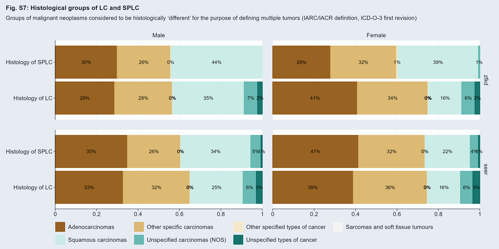

Figure 1

## Table S8: Frequency of same-histology SPLC by region

Table S8: Frequency of same-histology SPLC by region

| Regional Registry | Same group (%) | Different group (%) | Total (%) |
| --- | --- | --- | --- |
| **Analysis Dataset – Germany (11 PBCR)** |  |  |  |
| DEF Schleswig-Holstein | 0 | 97 (100.0%) | 97 (100.0%) |
| DE6 Hamburg | 0 | 7 (100.0%) | 7 (100.0%) |
| DE9 Lower Saxony | 0 | 53 (100.0%) | 53 (100.0%) |
| DE5 Bremen | 0 | 18 (100.0%) | 18 (100.0%) |
| DEA3 Muenster | 0 | 77 (100.0%) | 77 (100.0%) |
| DE2 Bavaria | 0 | 87 (100.0%) | 87 (100.0%) |
| DE4 Brandenburg | 0 | 67 (100.0%) | 67 (100.0%) |
| DED Saxony | 0 | 61 (100.0%) | 61 (100.0%) |
| DEG Thuringia | 0 | 43 (100.0%) | 43 (100.0%) |
| DE8 Mecklenburg-Western Pomerania | 0 | 32 (100.0%) | 32 (100.0%) |
| **Validation Dataset – United States (17 PBCR)** |  |  |  |
| SEER Reg 01 - San Francisco-Oakland SMSA | 107 (44.6%) | 133 (55.4%) | 240 (100.0%) |
| SEER Reg 02 - Connecticut | 188 (40.9%) | 272 (59.1%) | 460 (100.0%) |
| SEER Reg 20 - Detroit (Metropolitan) | 237 (46.4%) | 274 (53.6%) | 511 (100.0%) |
| SEER Reg 21 - Hawaii | 45 (49.5%) | 46 (50.5%) | 91 (100.0%) |
| SEER Reg 22 - Iowa | 134 (38.4%) | 215 (61.6%) | 349 (100.0%) |
| SEER Reg 23 - New Mexico | 31 (47.7%) | 34 (52.3%) | 65 (100.0%) |
| SEER Reg 25 - Seattle (Puget Sound) | 190 (44.3%) | 239 (55.7%) | 429 (100.0%) |
| SEER Reg 26 - Utah | 26 (54.2%) | 22 (45.8%) | 48 (100.0%) |
| SEER Reg 27 - Atlanta (Metropolitan) | 97 (44.5%) | 121 (55.5%) | 218 (100.0%) |
| SEER Reg 29 - Alaska Natives | 3 (37.5%) | 5 (62.5%) | 8 (100.0%) |
| SEER Reg 31 - San Jose-Monterey | 52 (50.0%) | 52 (50.0%) | 104 (100.0%) |
| SEER Reg 35 - Los Angeles | 214 (46.0%) | 251 (54.0%) | 465 (100.0%) |
| SEER Reg 37 - Rural Georgia | 3 (27.3%) | 8 (72.7%) | 11 (100.0%) |
| SEER Reg 41 - California excluding SF/SJM/LA | 607 (47.0%) | 684 (53.0%) | 1291 (100.0%) |
| SEER Reg 42 - Kentucky | 389 (42.5%) | 527 (57.5%) | 916 (100.0%) |
| SEER Reg 44 - New Jersey | 388 (39.9%) | 585 (60.1%) | 973 (100.0%) |
| SEER Reg 47 - Georgia excluding Atlanta/Rural Georgia | 287 (41.1%) | 411 (58.9%) | 698 (100.0%) |

Groups of malignant neoplasms considered to be histologically ‘different’ according to IARC ICD-O-3, revision 1 (2013).

## Figure S9: Relative risk for SPLC in lung cancer survivors stratified by follow-up time

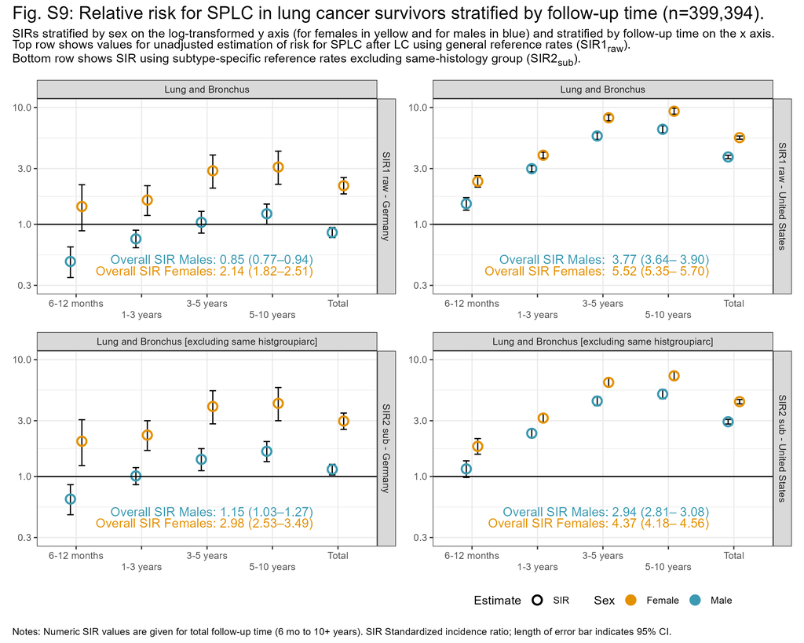

Figure 2

## Table S10: Sensitivity analysis A – Risk of SPLC using unadjusted and histology-specific SIR method [restricted to six German PBCR with low DCO rate]

S9. Table: Sensitivity analysis A – Risk for SPLC using unadjusted and histology-specific SIR method [restricted to six German PBCR with low DCO rate]

Comparing results for Germany (IARC/IACR MP rules) and United States (Verification dataset - SEER MP rules)

|  | **Germany (6 of 11 regions)** (Sensitivity dataset - IARC/IACR MP rules) SIR1<sub>raw</sub> | **Germany (6 of 11 regions)** (Sensitivity dataset - IARC/IACR MP rules) **SIR2<sub>sub</sub>** | **Germany (6 of 11 regions)** (Sensitivity dataset - IARC/IACR MP rules) 95% CI<sub>SIR2</sub> | **Germany (6 of 11 regions)** (Sensitivity dataset - IARC/IACR MP rules) O<sub>SIR2</sub> | **Germany (6 of 11 regions)** (Sensitivity dataset - IARC/IACR MP rules) | **Difference to main analysis** Δ SIR1<sub>raw</sub> | **Difference to main analysis** **Δ SIR2<sub>sub</sub>** | **Germany (all regions)** (Main analysis dataset - IARC/IACR MP rules) SIR1<sub>raw</sub> | **Germany (all regions)** (Main analysis dataset - IARC/IACR MP rules) **SIR2<sub>sub</sub>** | **Germany (all regions)** (Main analysis dataset - IARC/IACR MP rules) 95% CI<sub>SIR2</sub> | **United States** (Validation dataset - SEER MP rules) SIR1<sub>raw</sub> | **United States** (Validation dataset - SEER MP rules) **SIR2<sub>sub</sub>** | **United States** (Validation dataset - SEER MP rules) 95% CI<sub>SIR2</sub> |
| --- | --- | --- | --- | --- | --- | --- | --- | --- | --- | --- | --- | --- | --- |
| **Females** |  |  |  |  |  |  |  |  |  |  |  |  |  |
| Total - All lung cancers | 1.64 | 2.30 | 1.50–3.37 | 26 |  | −0.50 | −0.68 | 2.14 | 2.98 | 2.53–3.49 | 5.52 | 4.37 | 4.18–4.56 |
| Histology of LC |  |  |  |  |  |  |  |  |  |  |  |  |  |
| Adenocarcinoma (AC) | 1.05 | 1.58 | 0.68–3.11 | 8 |  | −0.64 | −0.95 | 1.69 | 2.53 | 1.91–3.28 | 6.08 | 4.48 | 4.20–4.76 |
| Large cell carcinoma (LCC) | 1.44 | 1.69 | 0.04–9.40 | x |  | 1.20 | 1.40 | 0.24 | 0.29 | 0.01–1.60 | 4.04 | 3.95 | 3.27–4.73 |
| Other & unspecified (O&U) | 1.18 | 1.67 | 0.34–4.88 | x |  | −0.10 | −0.13 | 1.28 | 1.80 | 0.98–3.01 | 4.04 | 3.88 | 3.49–4.30 |
| Small cell carcinoma (SCLC) | 2.92 | 4.29 | 1.58–9.35 | 6 |  | 0.49 | 0.72 | 2.43 | 3.57 | 2.26–5.35 | 4.26 | 4.51 | 3.79–5.32 |
| Squamous cell carcinoma (SCC) | 2.71 | 3.25 | 1.41–6.41 | 8 |  | −1.64 | −1.92 | 4.35 | 5.17 | 3.94–6.67 | 6.50 | 4.66 | 4.26–5.09 |
| Age at diagnosis of LC |  |  |  |  |  |  |  |  |  |  |  |  |  |
| 30 - 49 | 5.92 | 9.32 | 1.13–33.68 | x |  | 1.72 | 2.93 | 4.20 | 6.39 | 2.57–13.17 | 37.95 | 32.88 | 26.97–39.70 |
| 50 - 59 | 3.28 | 4.95 | 2.14–9.75 | 8 |  | −0.28 | −0.27 | 3.56 | 5.22 | 3.79–7.00 | 14.29 | 12.06 | 10.85–13.37 |
| 60 - 69 | 1.28 | 1.82 | 0.73–3.75 | 7 |  | −1.09 | −1.53 | 2.37 | 3.35 | 2.59–4.26 | 7.23 | 5.94 | 5.54–6.36 |
| 70 - 79 | 1.50 | 2.05 | 0.94–3.89 | 9 |  | 0.16 | 0.24 | 1.34 | 1.81 | 1.24–2.55 | 3.90 | 3.06 | 2.83–3.30 |
| 80+ | 0.00 | 0.00 | 0.00–2.96 | 0 |  | −0.82 | −1.06 | 0.82 | 1.06 | 0.34–2.47 | 2.05 | 1.55 | 1.30–1.83 |
| Year of diagnosis of LC |  |  |  |  |  |  |  |  |  |  |  |  |  |
| 2002 - 2005 | 1.00 | 1.37 | 0.28–4.01 | x |  | −1.27 | −1.70 | 2.27 | 3.07 | 2.31–3.99 | 5.71 | 4.44 | 4.15–4.74 |
| 2006 - 2009 | 1.76 | 2.46 | 1.31–4.21 | 13 |  | −0.15 | −0.20 | 1.91 | 2.66 | 1.99–3.48 | 5.61 | 4.48 | 4.18–4.80 |
| 2010 - 2013 | 1.82 | 2.60 | 1.25–4.78 | 10 |  | −0.49 | −0.73 | 2.31 | 3.33 | 2.44–4.44 | 5.00 | 4.02 | 3.63–4.44 |
| **Males** |  |  |  |  |  |  |  |  |  |  |  |  |  |
| Total - All lung cancers | 0.73 | 0.99 | 0.78–1.23 | 80 |  | −0.12 | −0.16 | 0.85 | 1.15 | 1.03–1.27 | 3.77 | 2.94 | 2.81–3.08 |
| Histology of LC |  |  |  |  |  |  |  |  |  |  |  |  |  |
| Adenocarcinoma (AC) | 0.77 | 1.03 | 0.68–1.50 | 27 |  | −0.16 | −0.19 | 0.93 | 1.22 | 1.02–1.45 | 4.19 | 3.13 | 2.91–3.37 |
| Large cell carcinoma (LCC) | 0.00 | 0.00 | 0.00–0.76 | 0 |  | −0.04 | −0.04 | 0.04 | 0.04 | 0.00–0.24 | 2.79 | 2.92 | 2.42–3.48 |
| Other & unspecified (O&U) | 0.53 | 0.68 | 0.27–1.41 | 7 |  | −0.27 | −0.36 | 0.80 | 1.04 | 0.74–1.41 | 2.68 | 2.58 | 2.29–2.89 |
| Small cell carcinoma (SCLC) | 0.96 | 1.28 | 0.61–2.35 | 10 |  | −0.07 | −0.08 | 1.03 | 1.36 | 0.99–1.81 | 3.09 | 3.38 | 2.80–4.04 |
| Squamous cell carcinoma (SCC) | 0.79 | 1.13 | 0.79–1.56 | 36 |  | −0.10 | −0.12 | 0.89 | 1.25 | 1.07–1.46 | 4.22 | 2.86 | 2.62–3.11 |
| Age at diagnosis of LC |  |  |  |  |  |  |  |  |  |  |  |  |  |
| 30 - 49 | 1.57 | 2.20 | 0.06–12.27 | x |  | −0.07 | −0.04 | 1.64 | 2.24 | 0.73–5.22 | 26.40 | 22.55 | 17.33–28.86 |
| 50 - 59 | 1.40 | 1.94 | 1.00–3.39 | 12 |  | −0.21 | −0.26 | 1.61 | 2.20 | 1.70–2.81 | 10.10 | 8.01 | 7.14–8.95 |
| 60 - 69 | 0.84 | 1.16 | 0.80–1.61 | 34 |  | −0.32 | −0.41 | 1.16 | 1.57 | 1.37–1.80 | 4.79 | 3.74 | 3.46–4.03 |
| 70 - 79 | 0.63 | 0.86 | 0.59–1.21 | 32 |  | 0.10 | 0.15 | 0.53 | 0.71 | 0.58–0.86 | 2.73 | 2.16 | 1.99–2.35 |
| 80+ | 0.10 | 0.13 | 0.00–0.73 | x |  | −0.10 | −0.12 | 0.20 | 0.25 | 0.10–0.51 | 1.60 | 1.26 | 1.06–1.49 |
| Year of diagnosis of LC |  |  |  |  |  |  |  |  |  |  |  |  |  |
| 2002 - 2005 | 0.50 | 0.68 | 0.36–1.16 | 13 |  | −0.29 | −0.37 | 0.79 | 1.05 | 0.89–1.22 | 3.71 | 2.92 | 2.72–3.13 |
| 2006 - 2009 | 0.87 | 1.17 | 0.86–1.56 | 47 |  | −0.07 | −0.09 | 0.94 | 1.26 | 1.07–1.48 | 4.07 | 3.15 | 2.92–3.40 |
| 2010 - 2013 | 0.67 | 0.92 | 0.56–1.42 | 20 |  | −0.17 | −0.23 | 0.84 | 1.15 | 0.90–1.44 | 3.30 | 2.59 | 2.30–2.91 |

Notes: The six included registries are Brandenburg 2007 to 2014, Bremen 2004 to 2014, Hamburg 2008 to 2014, Mecklenburg-Western Pomerania 2003 to 2011, Saarland 2002 to 2011 and Saxony 2005 to 2014. O<sub>SIR1</sub> number of cases observed in the data for SIR1<sub>raw</sub>; O<sub>SIR2</sub> number of cases observed in the data for SIR2<sub>sub</sub>, ZfKD data O<sub>SIR1</sub> = O<sub>SIR2</sub>; SEER Surveillance, Epidemiology, and End Results Program; SIR standardized incidence ratio; SIR1<sub>raw</sub> unadjusted SIR using age-, sex-, region-, period-specific reference rates; SIR2<sub>sub</sub> histological subtype-specific SIR using age-, sex-, region-, period- and histology-specific reference rates and excluding same-histology group SPLC from observed and expected; SIR3<sub>IARC</sub> unadjusted SIR but only counting international primaries (IARC/IACR MP rules), for ZfKD data SIR1<sub>raw</sub> = SIR3<sub>IARC</sub>; SIR4<sub>subIARC</sub> histological subtype-specific SIR but only counting international primaries (IARC/IACR MP rules), for ZfKD data SIR2<sub>sub</sub> = SIR4<sub>subIARC</sub>; SPLC second primary lung cancer; x censored counts of observed smaller than 5 for data privacy reasons; ZfKD German Centre for Cancer Registry Data

## Table S11: Sensitivity analysis B – Risk of SPLC using unadjusted and histology-specific SIR method [SEER restricted to White population]

S10. Table: Sensitivity analysis B – Risk for SPLC using unadjusted and histology-specific SIR method [SEER restricted to White population]

Comparing results for Germany (IARC/IACR MP rules) and United States (Sensitivity dataset - SEER MP rules)

|  | **Germany** (Analysis dataset - IARC/IACR MP rules) SIR1<sub>raw</sub> | **Germany** (Analysis dataset - IARC/IACR MP rules) **SIR2<sub>sub</sub>** | **Germany** (Analysis dataset - IARC/IACR MP rules) 95% CI<sub>SIR2</sub> | **Germany** (Analysis dataset - IARC/IACR MP rules) O<sub>SIR2</sub> | **Germany** (Analysis dataset - IARC/IACR MP rules) | **United States (White)** (Sensitivity dataset - SEER MP rules) SIR1<sub>raw</sub> | **United States (White)** (Sensitivity dataset - SEER MP rules) **SIR2<sub>sub</sub>** | **United States (White)** (Sensitivity dataset - SEER MP rules) 95% CI<sub>SIR2</sub> | **United States (White)** (Sensitivity dataset - SEER MP rules) SIR3<sub>IARC</sub> | **United States (White)** (Sensitivity dataset - SEER MP rules) SIR4<sub>subIARC</sub> | **United States (White)** (Sensitivity dataset - SEER MP rules) O<sub>SIR1</sub> | **United States (White)** (Sensitivity dataset - SEER MP rules) O<sub>SIR2</sub> | **United States (White)** (Sensitivity dataset - SEER MP rules) | **Difference to main analysis** (US White - All races) Δ SIR1<sub>raw</sub> | **Difference to main analysis** (US White - All races) **Δ SIR2<sub>sub</sub>** | **United States (All races)** (Validation dataset - SEER MP rules) SIR1<sub>raw</sub> | **United States (All races)** (Validation dataset - SEER MP rules) **SIR2<sub>sub</sub>** | **United States (All races)** (Validation dataset - SEER MP rules) 95% CI<sub>SIR2</sub> |
| --- | --- | --- | --- | --- | --- | --- | --- | --- | --- | --- | --- | --- | --- | --- | --- | --- | --- | --- |
| **Females** |  |  |  |  |  |  |  |  |  |  |  |  |  |  |  |  |  |  |
| Total - All lung cancers | 2.14 | 2.98 | 2.53–3.49 | 154 |  | 5.46 | 4.30 | 4.11–4.50 | 2.48 | 3.50 | 3,328 | 1,858 |  | −0.06 | −0.07 | 5.52 | 4.37 | 4.18–4.56 |
| Histology of LC |  |  |  |  |  |  |  |  |  |  |  |  |  |  |  |  |  |  |
| Adenocarcinoma (AC) | 1.69 | 2.53 | 1.91–3.28 | 57 |  | 6.04 | 4.40 | 4.11–4.70 | 2.59 | 3.89 | 1,800 | 872 |  | −0.04 | −0.08 | 6.08 | 4.48 | 4.20–4.76 |
| Large cell carcinoma (LCC) | 0.24 | 0.29 | 0.01–1.60 | x |  | 4.24 | 4.23 | 3.48–5.09 | 0.33 | 0.37 | 128 | 112 |  | 0.20 | 0.28 | 4.04 | 3.95 | 3.27–4.73 |
| Other & unspecified (O&U) | 1.28 | 1.80 | 0.98–3.01 | 14 |  | 3.94 | 3.76 | 3.35–4.20 | 2.02 | 2.94 | 481 | 315 |  | −0.10 | −0.12 | 4.04 | 3.88 | 3.49–4.30 |
| Small cell carcinoma (SCLC) | 2.43 | 3.57 | 2.26–5.35 | 23 |  | 4.24 | 4.53 | 3.77–5.39 | 2.53 | 3.99 | 187 | 127 |  | −0.02 | 0.02 | 4.26 | 4.51 | 3.79–5.32 |
| Squamous cell carcinoma (SCC) | 4.35 | 5.17 | 3.94–6.67 | 59 |  | 6.38 | 4.54 | 4.13–4.99 | 3.25 | 3.92 | 732 | 432 |  | −0.12 | −0.12 | 6.50 | 4.66 | 4.26–5.09 |
| Age at diagnosis of LC |  |  |  |  |  |  |  |  |  |  |  |  |  |  |  |  |  |  |
| 30 - 49 | 4.20 | 6.39 | 2.57–13.17 | 7 |  | 38.65 | 32.92 | 26.29–40.70 | 16.32 | 25.68 | 157 | 85 |  | 0.70 | 0.04 | 37.95 | 32.88 | 26.97–39.70 |
| 50 - 59 | 3.56 | 5.22 | 3.79–7.00 | 44 |  | 14.61 | 11.97 | 10.65–13.40 | 6.65 | 10.12 | 559 | 301 |  | 0.32 | −0.09 | 14.29 | 12.06 | 10.85–13.37 |
| 60 - 69 | 2.37 | 3.35 | 2.59–4.26 | 66 |  | 7.25 | 5.94 | 5.52–6.39 | 3.34 | 4.85 | 1,291 | 728 |  | 0.02 | 0.00 | 7.23 | 5.94 | 5.54–6.36 |
| 70 - 79 | 1.34 | 1.81 | 1.24–2.55 | 32 |  | 3.90 | 3.06 | 2.82–3.31 | 1.74 | 2.44 | 1,102 | 617 |  | 0.00 | 0.00 | 3.90 | 3.06 | 2.83–3.30 |
| 80+ | 0.82 | 1.06 | 0.34–2.47 | 5 |  | 2.07 | 1.60 | 1.33–1.90 | 0.97 | 1.29 | 219 | 127 |  | 0.02 | 0.05 | 2.05 | 1.55 | 1.30–1.83 |
| Year of diagnosis of LC |  |  |  |  |  |  |  |  |  |  |  |  |  |  |  |  |  |  |
| 2002 - 2005 | 2.27 | 3.07 | 2.31–3.99 | 55 |  | 5.62 | 4.39 | 4.10–4.71 | 2.59 | 3.61 | 1,436 | 804 |  | −0.09 | −0.05 | 5.71 | 4.44 | 4.15–4.74 |
| 2006 - 2009 | 1.91 | 2.66 | 1.99–3.48 | 53 |  | 5.58 | 4.42 | 4.10–4.75 | 2.56 | 3.62 | 1,289 | 722 |  | −0.03 | −0.06 | 5.61 | 4.48 | 4.18–4.80 |
| 2010 - 2013 | 2.31 | 3.33 | 2.44–4.44 | 46 |  | 4.92 | 3.89 | 3.48–4.33 | 2.12 | 3.04 | 603 | 332 |  | −0.08 | −0.13 | 5.00 | 4.02 | 3.63–4.44 |
| **Males** |  |  |  |  |  |  |  |  |  |  |  |  |  |  |  |  |  |  |
| Total - All lung cancers | 0.85 | 1.15 | 1.03–1.27 | 388 |  | 3.79 | 2.91 | 2.77–3.07 | 1.71 | 2.33 | 2,651 | 1,498 |  | 0.02 | −0.03 | 3.77 | 2.94 | 2.81–3.08 |
| Histology of LC |  |  |  |  |  |  |  |  |  |  |  |  |  |  |  |  |  |  |
| Adenocarcinoma (AC) | 0.93 | 1.22 | 1.02–1.45 | 132 |  | 4.21 | 3.08 | 2.84–3.34 | 1.97 | 2.77 | 1,136 | 591 |  | 0.02 | −0.05 | 4.19 | 3.13 | 2.91–3.37 |
| Large cell carcinoma (LCC) | 0.04 | 0.04 | 0.00–0.24 | x |  | 2.68 | 2.78 | 2.26–3.39 | 0.27 | 0.31 | 108 | 98 |  | −0.11 | −0.14 | 2.79 | 2.92 | 2.42–3.48 |
| Other & unspecified (O&U) | 0.80 | 1.04 | 0.74–1.41 | 40 |  | 2.68 | 2.55 | 2.24–2.89 | 1.35 | 1.87 | 351 | 241 |  | 0.00 | −0.03 | 2.68 | 2.58 | 2.29–2.89 |
| Small cell carcinoma (SCLC) | 1.03 | 1.36 | 0.99–1.81 | 46 |  | 3.03 | 3.29 | 2.68–4.00 | 2.05 | 3.02 | 135 | 100 |  | −0.06 | −0.09 | 3.09 | 3.38 | 2.80–4.04 |
| Squamous cell carcinoma (SCC) | 0.89 | 1.25 | 1.07–1.46 | 169 |  | 4.29 | 2.89 | 2.63–3.16 | 1.80 | 2.38 | 921 | 468 |  | 0.07 | 0.03 | 4.22 | 2.86 | 2.62–3.11 |
| Age at diagnosis of LC |  |  |  |  |  |  |  |  |  |  |  |  |  |  |  |  |  |  |
| 30 - 49 | 1.64 | 2.24 | 0.73–5.22 | 5 |  | 29.60 | 24.40 | 18.17–32.08 | 14.74 | 20.96 | 88 | 51 |  | 3.20 | 1.85 | 26.40 | 22.55 | 17.33–28.86 |
| 50 - 59 | 1.61 | 2.20 | 1.70–2.81 | 65 |  | 10.80 | 8.38 | 7.36–9.50 | 4.60 | 6.44 | 441 | 244 |  | 0.70 | 0.37 | 10.10 | 8.01 | 7.14–8.95 |
| 60 - 69 | 1.16 | 1.57 | 1.37–1.80 | 207 |  | 4.90 | 3.77 | 3.47–4.09 | 2.17 | 3.00 | 1,023 | 568 |  | 0.11 | 0.03 | 4.79 | 3.74 | 3.46–4.03 |
| 70 - 79 | 0.53 | 0.71 | 0.58–0.86 | 104 |  | 2.76 | 2.16 | 1.98–2.35 | 1.30 | 1.78 | 903 | 519 |  | 0.03 | 0.00 | 2.73 | 2.16 | 1.99–2.35 |
| 80+ | 0.20 | 0.25 | 0.10–0.51 | 7 |  | 1.63 | 1.26 | 1.04–1.52 | 0.70 | 0.92 | 196 | 116 |  | 0.03 | 0.00 | 1.60 | 1.26 | 1.06–1.49 |
| Year of diagnosis of LC |  |  |  |  |  |  |  |  |  |  |  |  |  |  |  |  |  |  |
| 2002 - 2005 | 0.79 | 1.05 | 0.89–1.22 | 156 |  | 3.73 | 2.87 | 2.66–3.10 | 1.70 | 2.29 | 1,160 | 662 |  | 0.02 | −0.05 | 3.71 | 2.92 | 2.72–3.13 |
| 2006 - 2009 | 0.94 | 1.26 | 1.07–1.48 | 157 |  | 4.05 | 3.09 | 2.84–3.35 | 1.79 | 2.45 | 1,052 | 588 |  | −0.02 | −0.06 | 4.07 | 3.15 | 2.92–3.40 |
| 2010 - 2013 | 0.84 | 1.15 | 0.90–1.44 | 75 |  | 3.40 | 2.67 | 2.35–3.02 | 1.57 | 2.19 | 439 | 248 |  | 0.10 | 0.08 | 3.30 | 2.59 | 2.30–2.91 |

Notes: This sensitivity analysis replicates Table 3, with SEER data restricted to White population only. O<sub>SIR1</sub> number of cases observed in the data for SIR1<sub>raw</sub>; O<sub>SIR2</sub> number of cases observed in the data for SIR2<sub>sub</sub>, ZfKD data O<sub>SIR1</sub> = O<sub>SIR2</sub>; SEER Surveillance, Epidemiology, and End Results Program; SIR standardized incidence ratio; SIR1<sub>raw</sub> unadjusted SIR using age-, sex-, region-, period-specific reference rates; SIR2<sub>sub</sub> histological subtype-specific SIR using age-, sex-, region-, period- and histology-specific reference rates and excluding same-histology group SPLC from observed and expected; SIR3<sub>IARC</sub> unadjusted SIR but only counting international primaries (IARC/IACR MP rules), for ZfKD data SIR1<sub>raw</sub> = SIR3<sub>IARC</sub>; SIR4<sub>subIARC</sub> histological subtype-specific SIR but only counting international primaries (IARC/IACR MP rules), for ZfKD data SIR2<sub>sub</sub> = SIR4<sub>subIARC</sub>; SPLC second primary lung cancer; x censored counts of observed smaller than 5 for data privacy reasons; ZfKD German Centre for Cancer Registry Data

## References

1. Thakur MK, Ruterbusch JJ, Schwartz AG, Gadgeel SM, Beebe-Dimmer JL, Wozniak AJ. [Risk of Second Lung Cancer in Patients with Previously Treated Lung Cancer: Analysis of Surveillance, Epidemiology, and End Results (SEER) Data](https://doi.org/10.1016/j.jtho.2017.09.1964). J Thorac Oncol. 2018;13:46–53.